# LifePort hypothermic machine perfusion data analysis

Showcase with code

Author

Simon Schwab

Published

March 26, 2025

Abstract

This report demonstrates how to import LifePort hypothermic machine perfusion data for research and data analysis in R.

## Objectives

This showcase imports 50 LifePort raw data sets and performs descriptive statistics. This report was created using R, RStudio, Quarto, and the Swisstransplant package (`swt`). I hope this work will advance research and analysis of perfusion data.

## Data import

```r
library(fs)
library(swt)
library(ggplot2)
library(gridExtra)

col = swt::swt_colors()
```

If these packages are not already installed, you can install them using:

```r
install.packages("foo")
```

The Swisstransplant package (`swt`) can be installed from GitHub using the `remotes` package:

```r
remotes::install_github("Swisstransplant/swt")
```

Below, I define the path where the data is located in the variable `PATH_DATA`.

```r
PATH_DATA = file.path(path_home(), "OneDrive - Swisstransplant",
                      "Data", "Lifeport Rawdata", "2024")
files = list.files(PATH_DATA, pattern = ".txt|.TXT")
files = files[1:50] # only use 50 cases
```

### Raw data files

I read each data file, one by one, from the first to the total number of files `length(files)`, using a for loop. The LifePort data are processed in three steps:

1. **Read** the data file with `lifeport_read()`
2. **Process** the data (e.g., signal filtering) with `lifeport_process()`
3. **Calculate** the statistical indicators with `lifeport_sumstats()`

For more details, refer to the publication at the end.

Reading hundreds of files will inevitably lead to errors, especially if a LifePort data file is corrupt or empty. To handle this, the problematic file must be identified and removed from the data folder. Debugging can be done by adding a `print(i)` statement in the loop to determine which file (`files[i]`) caused the issue.

```r
data.device = list()
data.organ = list()
data.timeseries = list()
data.sumstats = list()

for (i in 1:length(files)) {

  # print(i) # for debugging

  tmp = lifeport_read(file = file.path(PATH_DATA, files[i]), format = "guess")
  tmp = lifeport_process(lpdat = tmp, window_size = 15)
  tmp = lifeport_sumstats(lpdat = tmp, ice_threshold = 2.5)

  # add filename as well
  tmp$data.device$Filename = files[i]

  data.device[[i]]     = tmp$data.device
  data.organ[[i]]      = tmp$data.organ
  data.timeseries[[i]] = tmp$data
  data.sumstats[[i]]   = tmp$data.sumstats
}

data.device = data.table::rbindlist(data.device)
data.organ = data.table::rbindlist(data.organ)
data.sumstats = data.table::rbindlist(data.sumstats)
```

The code above is designed to collect all the data and store it temporarily in different lists. Once all the data has been read and processed, the lists can be transformed into data frames.

### Data access in R

#### Device data

The device data contains the serial number, the name of the device, the start, stop, and run time.

```r
n = 5

data.device[1:n, -c("Filename", "Type", "SubType", "DataState", "HasGaps")]
```

| SerialNumber | UnitID | FirmwareVersion | FileID | StartTime | Runtime | StopTime |
| --- | --- | --- | --- | --- | --- | --- |
| 2326506 |  | 768 | 7 | 2024-01-02 00:59:26 | 06:11:10 | 2024-01-02 07:10:26 |
| 1415442 | DIEGEM_LOANER | 515 | 10 | 2024-01-03 14:33:46 | 03:52:00 | 2024-01-03 18:25:36 |
| 1423194 | GDfL | 515 | 97 | 2024-01-03 14:23:42 | 02:29:40 | 2024-01-03 16:53:12 |
| 1415442 | DIEGEM_LOANER | 515 | 11 | 2024-01-08 14:23:37 | 03:16:10 | 2024-01-08 17:39:37 |
| 1423110 | SG1 | 515 | 48 | 2024-01-21 14:01:46 | 03:58:20 | 2024-01-21 17:59:56 |

**Note**

Ideally, the `UnitID` should be a short name without special characters. I believe the LifePort machines in Geneva have a special character in their `UnitID`. In such cases, the `UnitID` may not display correctly, and if it contains a name that could cause serious issues, it will be removed.

#### Organ data

Organ data includes the kidney side, blood type, and cross-clamp time. This information is entered into the device by healthcare professionals and may be missing if not entered.

```r
data.organ[1:n, c("KidneySide", "BloodType", "CrossClampTime.Date")]
```

| KidneySide | BloodType | CrossClampTime.Date |
| --- | --- | --- |
| Right | 0 | 2024-01-01 23:51:00 |
| Left | 0 | 2024-03-01 12:32:00 |
| Right | 0 | 2024-01-03 12:32:00 |
| Right | 0 | NA |
| Left | A | NA |

#### Summary statistics data

The summary statistics data are particularly interesting as they include various values such as mean ice temperature, mean discharge, and more. See the publication at the end for more details.

```r
n = 10

data.sumstats[1:n, ]
```

| perfusion.dur | perfusion.dur.str | systolicPressure.md | diastolicPressure.mean | flowRate.mean | organResistance.mean | organResistance.sd | organResistance.x1 | organResistance.y1 | organResistance.x2 | organResistance.y2 | organResistance.delta | organResistance.slope | iceContainerTemperature.mean | iceContainerTemperature.sd | iceContainerTemperature.minAbove | iceContainerTemperature.minAbove.str | infuseTemperature.mean | infuseTemperature.sd | infuseTemperature.start | infuseTemperature.minAbove | infuseTemperature.minAbove.str |
| --- | --- | --- | --- | --- | --- | --- | --- | --- | --- | --- | --- | --- | --- | --- | --- | --- | --- | --- | --- | --- | --- |
| 368.83333 | 06:08:50 | 28.33333 | 19.67842 | 151.66601 | 0.1499605 | 0.0106282 | 8.00000 | 0.3328040 | 96.42424 | 0.2153304 | -0.1174736 | -0.0080094 | 2.354513 | 0.0728145 | 0.00000 | 00:00:00 | 6.778806 | 1.2528984 | 10.236667 | 7.1666667 | 00:07:10 |
| 35.66667 | 00:35:40 | 24.66667 | 21.93645 | 123.50081 | 0.1453492 | 0.0491878 | NA | NA | NA | NA | NA | NA | 1.873707 | 0.1100868 | 0.00000 | 00:00:00 | 6.424103 | 0.1477794 | 6.413333 | 0.0000000 | 00:00:00 |
| 142.16667 | 02:22:10 | 29.46667 | 21.78759 | 49.16569 | 0.5064565 | 0.0560590 | 8.00000 | 0.7881980 | 35.18270 | 0.6431914 | -0.1450066 | -0.0322236 | 1.313920 | 0.0794070 | 0.00000 | 00:00:00 | 6.253837 | 0.4731581 | 6.423333 | 0.0000000 | 00:00:00 |
| 193.83333 | 03:13:50 | 29.46667 | 20.69923 | 143.20896 | 0.1635259 | 0.0125971 | 8.00000 | 0.2880239 | 66.88864 | 0.1913324 | -0.0966915 | -0.0100026 | 2.342481 | 0.1482780 | 17.33333 | 00:17:20 | 6.552988 | 0.1423970 | 6.783333 | 0.0000000 | 00:00:00 |
| 189.33333 | 03:09:20 | 29.46667 | 20.68374 | 126.49927 | 0.1829073 | 0.0188346 | 8.00000 | 0.3763685 | 37.31903 | 0.2488760 | -0.1274925 | -0.0263778 | 1.908881 | 0.1506162 | 0.00000 | 00:00:00 | 5.136852 | 0.6166316 | 5.486667 | 0.0000000 | 00:00:00 |
| 475.33333 | 07:55:20 | 29.53333 | 16.02805 | 78.10237 | 0.2776885 | 0.0218842 | 60.00002 | 0.5077676 | 105.81427 | 0.3577929 | -0.1499747 | -0.0199968 | 1.995274 | 0.3623524 | 31.83333 | 00:31:50 | 4.955487 | 0.8323820 | 7.333333 | 0.1666667 | 00:00:10 |
| 26.66667 | 00:26:40 | 13.40000 | 10.02441 | NA | NA | NA | NA | NA | NA | NA | NA | NA | 1.657855 | 0.1108550 | 0.00000 | 00:00:00 | 8.026923 | 0.3899790 | 8.250000 | 0.0000000 | 00:00:00 |
| 336.33333 | 05:36:20 | 29.60000 | 16.03300 | 74.53828 | 0.2960289 | 0.0178520 | 8.00000 | 0.9659789 | 26.47657 | 0.5348632 | -0.4311158 | -0.1437060 | 1.656053 | 0.1851524 | 0.00000 | 00:00:00 | 6.060091 | 0.4616435 | 8.016667 | 0.0000000 | 00:00:00 |
| 103.16667 | 01:43:10 | 22.60000 | 19.86160 | 165.24365 | 0.1234410 | 0.0288686 | 32.66376 | 0.1663610 | 237.97514 | 0.1105713 | -0.0557897 | -0.0015989 | 2.139178 | 0.1180563 | 0.00000 | 00:00:00 | 7.204429 | 0.7044574 | 8.476667 | 0.0000000 | 00:00:00 |
| 262.00000 | 04:22:00 | 29.46667 | 19.01612 | 49.97994 | 0.4795192 | 0.0423279 | 8.00000 | 1.1968849 | 55.91632 | 0.7775040 | -0.4193810 | -0.0535380 | 1.519420 | 0.0863631 | 0.00000 | 00:00:00 | 6.450427 | 0.8935817 | 9.143333 | 0.0000000 | 00:00:00 |

#### Time series data

The complete time series data is also available. Below is an example for the first kidney, the first 10 samples, along with the filtered (smoothed) time series. Due to filtering, the first few and the last few values are missing.

```r
data.timeseries[[1]][1:10, c("FlowRate", "FlowRate.flt")]
```

| FlowRate | FlowRate.flt |
| --- | --- |
| 14 | NA |
| 10 | NA |
| 30 | NA |
| 52 | NA |
| 63 | NA |
| 67 | NA |
| 71 | NA |
| 75 | 61.86667 |
| 75 | 66.53333 |
| 77 | 71.40000 |

## Descriptive statistics

Here are some examples of how to visualize the data and perform some statistics.

### Plotting the data

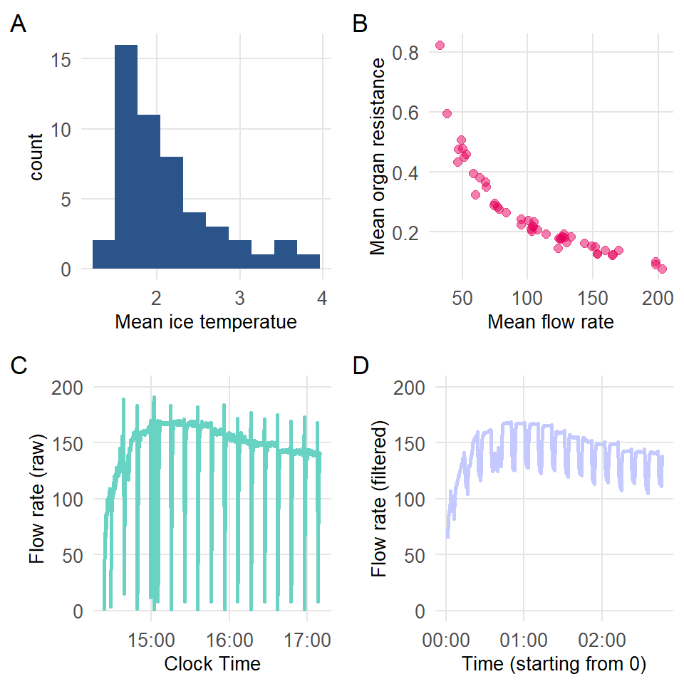

```r
k = 4 # which time series to show
t = 1:1000 # show first 100 seconds

p1 = ggplot(data.sumstats, aes(x = iceContainerTemperature.mean)) +
  geom_histogram(bins = 10, alpha = 1, fill = col$blue.alt) +
  xlab("Mean ice temperatue") +
  labs(tag = "A") + swt_style()

p2 = ggplot(data.sumstats, aes(x = flowRate.mean, y = organResistance.mean)) +
  geom_point(size = 2, alpha = 0.5, col = col$strongred.akzent) +
  scale_color_manual(values = col$blue.swt) +
  xlab("Mean flow rate") + ylab("Mean organ resistance") +
  labs(tag = "B") + swt_style()

p3 = ggplot(data.timeseries[[k]][t,], aes(x = time.clock, y = FlowRate)) +
  geom_line(size = 1, alpha = 1, col = col$turkis.tpx) +
  ylim(c(0, 200)) +
  xlab("Clock Time") + ylab("Flow rate (raw)") +
  labs(tag = "C") + swt_style()

p4 = ggplot(data.timeseries[[k]][t,], aes(x = time.zero, y = FlowRate.flt)) +
  geom_line(size = 1, alpha = 1, col = col$purple.alt) +
  ylim(c(0, 200)) +
  xlab("Time (starting from 0)") + ylab("Flow rate (filtered)") +
  labs(tag = "D") + swt_style()

grid.arrange(p1, p2, p3, p4, nrow = 2, ncol = 2)
```

```r
data.frame(median = median_iqr(data.sumstats$perfusion.dur/60))
```

| median |
| --- |
| 5.8 (from 3.4 to 8.4) |

To clarify, each kidney has a mean flow rate, and I calculate the median across all the mean flow rates.

```r
data.frame(median = median_iqr(data.sumstats$flowRate.mean))
```

| median |
| --- |
| 104.5 (from 68.4 to 133.0) |

## References

Please be sure to cite the following work in your research when utilizing EXAM or the Swisstranplant `swt` package for machine perfusion data analysis.

Schwab S, Steck H, Binet I, Elmer A, Ender W, Franscini N, Haidar F, Kuhn C, Sidler D, Storni F, Krügel N, Immer F. EXAM: Ex-vivo allograft monitoring dashboard for the analysis of hypothermic machine perfusion data in deceased-donor kidney transplantation. *PLOS Digit Health*. 2024;3(12):e0000691. [doi:10.1371/journal.pdig.0000691](https://doi.org/10.1371/journal.pdig.0000691)

Schwab S. EXAM: Ex Vivo Allograft Monitoring Dashboard. Github; 2025. Accessed February 13, 2025. https://github.com/Swisstransplant/EXAM

Schwab S. swt: Swisstransplant R Package. Github; 2024. Accessed February 13, 2025. https://github.com/Swisstransplant/swt

## Contact

Please feel free to contact me at simon.schwab@swisstransplant.org with any inquiries regarding the analysis of perfusion data; I’m happy to assist.